# Sunday_test

JR Sanders

October 22, 2017

## Background

To be able to predict the weight lifting routine of twenty cases. The data was gathered from accelerometers. Using devices such as Jawbone Up,and Nike FuelBand, and Fitbit it is now possible to collect a large amount of data about personal activity relatively inexpensively. These types of devices are part of the quantified self movement a group of enthusiasts who take measurements about themselves regularly to improve their health,to find patterns in their behavior, or because they are tech geeks. One thing that people regularly do is quantify how much of a particular activity they do but they rarely quantify how well they do it. In this project, the goal is to use data from accelerometers on the belt, forearm, arm and dumbell of six participants. They were asked to perform barbell lifts correctly and incorrectly in five different ways.

```r
Sys.info()
```

```
##        sysname        release        version       nodename        machine
##      "Windows"       "10 x64"  "build 15063"   "MICROVAX87"       "x86-64"
##          login           user effective_user
##      "jehuti1"      "jehuti1"      "jehuti1"
```

```r
Sys.time()
```

```
## [1] "2017-10-22 20:51:44 EDT"
```

## Loading required libraries and datasets

```r
setwd("C:/Users/jehuti1/Documents/2017_MachineLearning/projectml")
library(caret , quietly = TRUE )
library(randomForest , quietly = TRUE)
library(psych, quietly = TRUE)
```

```r
library(corrplot, quietly = TRUE)
traindsetq10 <- read.csv("pml-training.csv")
testdsetq10 <- read.csv("pml-testing.csv")
```

### Assessing the predictor columns NA count and removing extraneous columns

```r
colcount = ncol(traindsetq10)
rowcount = nrow(traindsetq10)
na = integer()
for (i in 1:colcount) {
# Add the amount of na's  in the column
# If it is more than half of the total number of columns remove it

  fraction = sum(is.na(traindsetq10[,i])) / rowcount
           if (fraction > 0.5) {
             na = c(na,i)
           }
}

traindsetq10 = traindsetq10[,-c(na)]
foremovable <- grepl("kurtosis|skewness|X|yaw|user_name|new_window|timestamp",colnames(traindsetq10))
traindsetq10 <-  traindsetq10[,!foremovable]
traindsetq10shorten <- data.frame()
traindsetq10shorten <- traindsetq10
colnames(traindsetq10shorten)
```

```
##  [1] "num_window"           "roll_belt"            "pitch_belt"
##  [4] "total_accel_belt"     "gyros_belt_x"         "gyros_belt_y"
##  [7] "gyros_belt_z"         "accel_belt_x"         "accel_belt_y"
## [10] "accel_belt_z"         "magnet_belt_x"        "magnet_belt_y"
## [13] "magnet_belt_z"        "roll_arm"             "pitch_arm"
## [16] "total_accel_arm"      "gyros_arm_x"          "gyros_arm_y"
## [19] "gyros_arm_z"          "accel_arm_x"          "accel_arm_y"
## [22] "accel_arm_z"          "magnet_arm_x"         "magnet_arm_y"
## [25] "magnet_arm_z"         "roll_dumbbell"        "pitch_dumbbell"
## [28] "total_accel_dumbbell" "gyros_dumbbell_x"     "gyros_dumbbell_y"
## [31] "gyros_dumbbell_z"     "accel_dumbbell_x"     "accel_dumbbell_y"
## [34] "accel_dumbbell_z"     "magnet_dumbbell_x"    "magnet_dumbbell_y"
## [37] "magnet_dumbbell_z"    "roll_forearm"         "pitch_forearm"
## [40] "total_accel_forearm"  "gyros_forearm_x"      "gyros_forearm_y"
## [43] "gyros_forearm_z"      "accel_forearm_x"      "accel_forearm_y"
## [46] "accel_forearm_z"      "magnet_forearm_x"     "magnet_forearm_y"
## [49] "magnet_forearm_z"     "classe"
```

### Partition data set to create a data set and validation set

```r
ptrain = createDataPartition(y = traindsetq10shorten$classe, p = 0.7,
                             list = FALSE)
usefortrain = traindsetq10shorten[ptrain,]
useforvalid = traindsetq10shorten[-ptrain,]
```

### Correlation Matrix

1. To explore the association between the predictors
2. To explore the possiblities of uncorrelated data
3. To confirm the use of principal component analysis

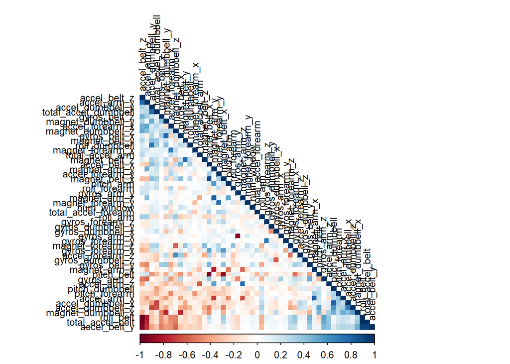

```r
corMatts <- cor(usefortrain[, -50])
corrplot(corMatts,order = "FPC", method = "color" , type = "lower", tl.cex = 0.8, tl.col = rgb(0,0,0))
```

### Scree Plots - Training Dataset Scree Plot

#### Used to determine how many components should be selected for the modeling stage

[figure not shown]

```r
# Correlation Plot

####### Training D Set Scree Plot
preProc351 <- preProcess(usefortrain[,-50], method = "pca", pcaComp = 35 )
trainpc <- predict(preProc351, usefortrain[, -50])
pca11 <- principal(trainpc, nfactors = 35, rotate = "none")
plot(pca11$values, type = "b", ylab = "Eigenvalues" , xlab = "Component"  )
```

### Validation Dataset Scree Plot

#### Used to suggest how many components could be selected for the modeling stage

[figure not shown]

```r
####### Validation Set Scree Plot
preProc351val <- preProcess(useforvalid[,-50], method = "pca", pcaComp = 35 )
trainpcv <- predict(preProc351val, useforvalid[, -50])
pcaval <- principal(trainpcv, nfactors = 35, rotate = "none")
plot(pcaval$values, type = "b", ylab = "Eigenvalues" , xlab = "Component"  )
```

```r
#############################
############# TRAINING OF MODEL
```

### Predictive Model Train Control

4-fold cross validation was employed.

###### The twenty predictions are not shown

```r
tcontrol <- trainControl(method = "cv" , number = 4)
```